# Box Jenkins - Identificación y Estimación

Universidad Nacional de Colombia - Facultad de Ciencias Económicas

Equipo de Monitores - Econometría II

2023-08-20

Para este script se considerarán las siguientes series de tiempo:

1. **índice de producción industrial**
2. **Spread entre la tasa de bonos norteamericanos a 5 años y T bills**
3. **Tasa de desempleo mensual EE.UU (1959 - 2012)**

# Carga y descarga de paquetes

Para el tratamiento de series temporales, estimación de modelos y comprobación de resultados requerimos de las funciones de algunos paquetes no nativos.

El proceso se realizará con el comando “pacman”, el cual carga los paquetes ya instalados y descarga (para posteriormente cargar) los no instalados

```r
pacman :: p_load(
  forecast,   # Para hacer pronóstico con los modelos ARIMA
  lmtest,     # Obtener la significancia individual de los coeficientes ARIMA
  urca,       # Prueba de raíz unitaria (estacionariedad)
  tseries,    # Para estimar modelos de series de tiempo y pruebas de supuestos
  readxl,     # Para leer archivos de excel
  stargazer,  # Presentación de resultados y tablas más estéticos
  psych,      # Para hacer estadística descriptiva
  seasonal,   # Para desestacionalizar las series de tiempo
  aTSA,       # Para hacer prueba de efectos ARCH
  astsa,      # Para estimar, validar y pronosticar en modelos ARIMA/SARIMA
  xts,        # Para utilizar objetos de tipo xts
  tidyverse,  # Conjunto de paquetes (incluye dplyr y ggplot2)
  readxl,     # Para leer archivo excel
  car         # Función qqplot
)
```

Antes de iniciar, procedemos a limpiar el environment

```r
rm(list = ls())
```

###### **Nota Importante :** En R uno puede trabajar series de tiempo con 3 objetos:

- ts : Intervalos de tiempo fijos, objeto estándar de series de tiempo en R)
- zoo
- xts: xts significa “extensible time series”. xts es una subclase de zoo. Son objetos que están diseñados para ser más flexibles y poderosos en términos de modelamiento; diseñados para facilitar el uso de las series temporales.  
  Además, son muy útiles para el modelamiento de series financieros con intervalos de tiempo que nos son fijos.

# 1. índice de Producción Industrial

## 1.1 Descripción

Vamos a trabajar con una serie del Industrial Production Index de los EE.UU (indprod), el cuál es un indicador económico que mide la producción real de los Estados Unidos en términos de manufactura, minería, electicidad y gas.

Observe que al tratarse de un índice, debe tener un año base de referencia, que en nuestro caso corresponde a 2012. Es decir que el valor del índice para el 2012 es igual a 100 (Index_2012 = 100). De forma análoga:

- Valores mayores a 100 indican que para ese año corriente la producción manufacturera fue mayor que en el año base.
- Valores menores a 100 indican que para ese año corriente la producción manufacturera fue menor que en el año base.

Fuente: https://fred.stlouisfed.org/series/INDPRO#0 (Tomados de la FRED de la Reserva Federa de St. Louis)

## 1.2 Identificación

### 1.2.1 Importación

Importamos la base de datos correspondiente al índice de producción industrial con el comando “file.choose()”

```r
base_fred <- read_excel(file.choose())
```

Como corresponde a una serie de tiempo, se convierte en objeto tipo ts y la visualizamos.

```r
indprod = ts(base_fred$INDPRO, start = 1960
             , frequency = 4) # 4 observaciones por año (1 cada trimestre)
View(indprod)
```

Visualicemos, además, la versión tipo xts de la serie de tiempo.

```r
indprod_xts = xts(base_fred$INDPRO,order.by = base_fred$observation_date)
View(indprod_xts)
```

La clase de cada objeto corresponde al tipo de objeto según su importación.

```r
class(indprod)
```

```
## [1] "ts"
```

```r
class(indprod_xts)
```

```
## [1] "xts" "zoo"
```

### 1.2.2 Gráficos y Estacionariedad

Consideremos primero el objeto ts.

En primer lugar, el paquete nativo de graficación de R puede realizar un gráfico de la serie temporal.

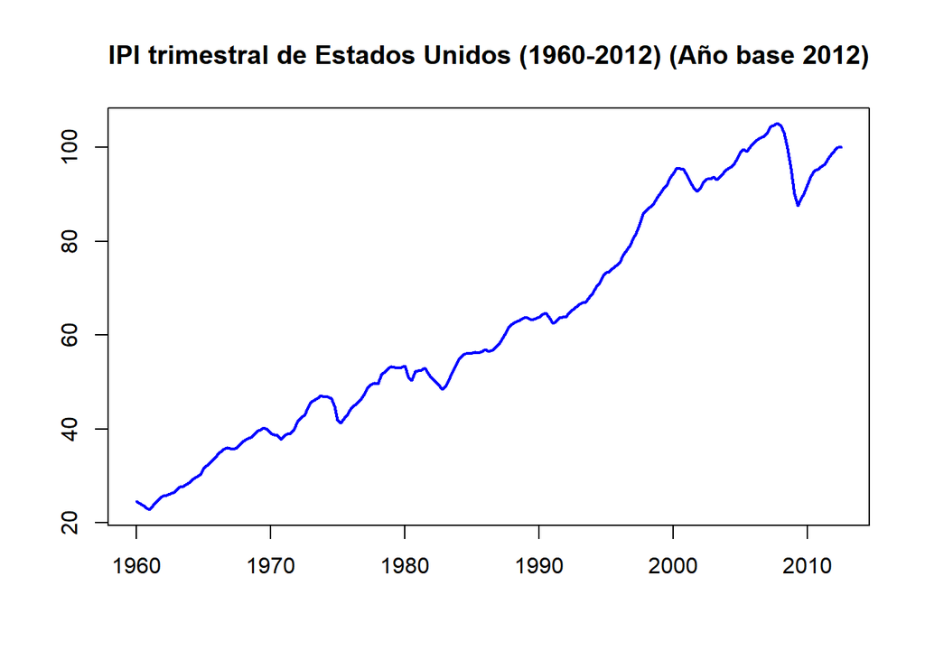

```r
x11() #Este comando llama al dispositivo gráfico para visualizar de forma ampliada

plot.ts(indprod, xlab="",ylab="", main="IPI trimestral de Estados Unidos (1960-2012) (Año base 2012)" ,lty=1, lwd=2, col="blue")
```

Sin embargo, “ggplot2” del paquete importado Tidyverse puede mejorar algunos aspectos estéticos del gráfico.

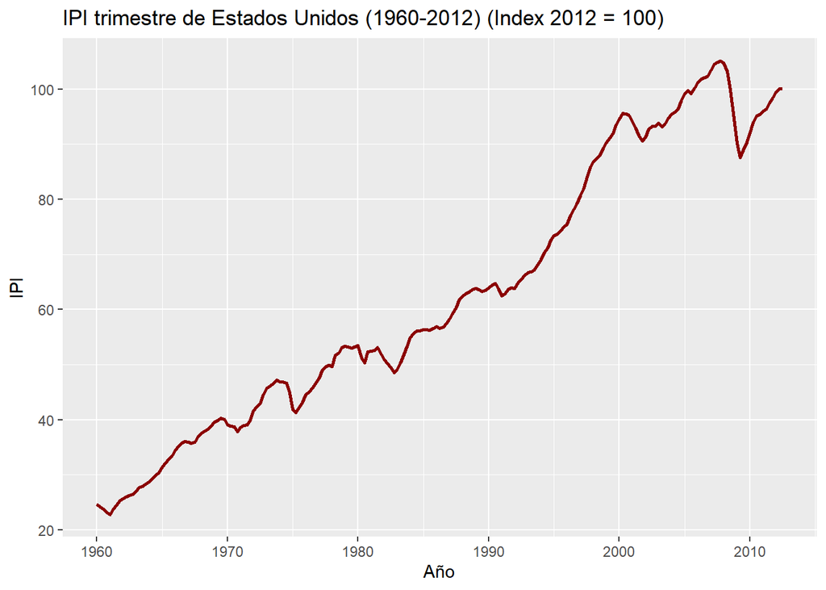

```r
autoplot(indprod, col="DarkRed", main = "IPI trimestre de Estados Unidos (1960-2012) (Index 2012 = 100)",xlab = "Año", ylab="IPI", lwd=1)
```

Para el objeto xts:

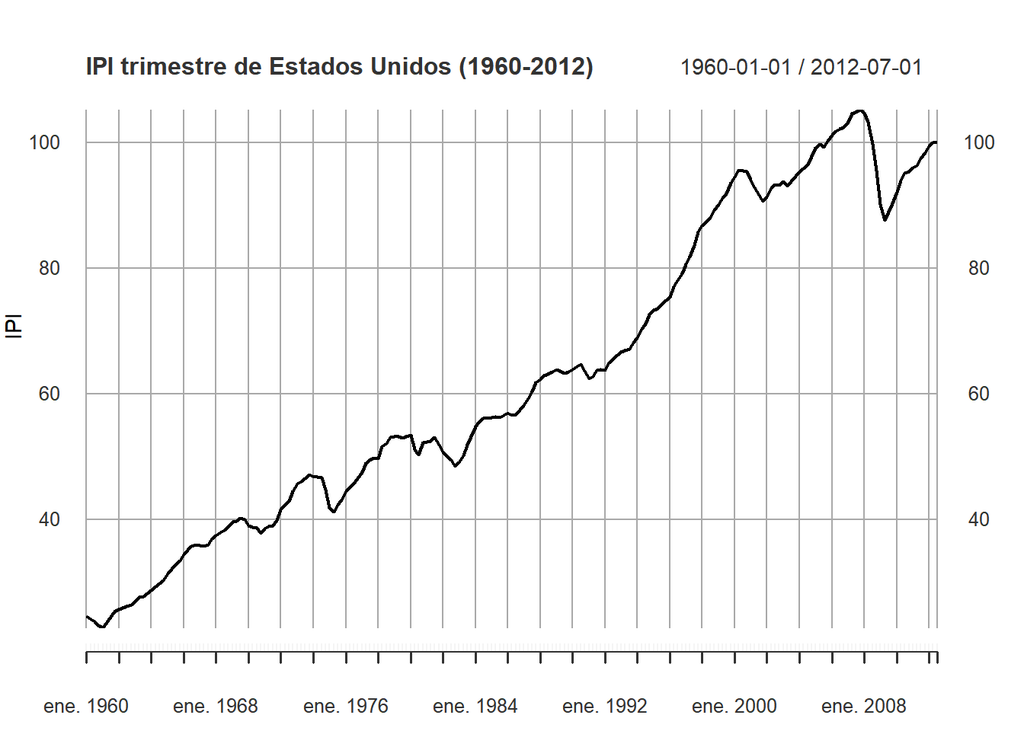

```r
x11()
plot(indprod_xts, main = "IPI trimestre de Estados Unidos (1960-2012)", ylab  = "IPI")
```

El objeto xts produce un gráfico más informativo y elaborado.

Continuando con la identificación de la serie temporal se debe gráficar los gráficos de autocorrelación y autocorrelación parcial.

Para poder visualizar ambos correlogramas simultaneamente, podemos crear una malla de gráficos con el comando “par(mfrow=c())”.

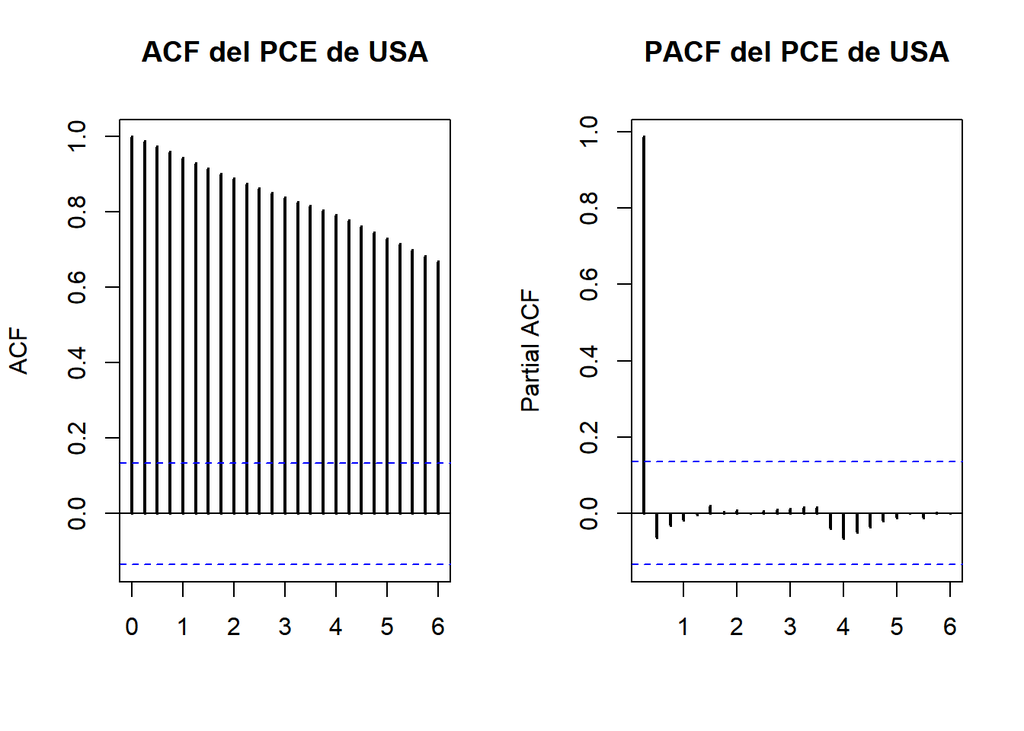

```r
lags=24 #Rezagos
par(mfrow=c(1,2)) #Malla de gráficos con 1 fila y 2 columnas
acf(indprod,lag.max=lags,plot=T,lwd=2,xlab='',main='ACF del PCE de USA')
pacf(indprod,lag.max=lags,plot=T,lwd=2,xlab='',main='PACF del PCE de USA')
```

Ggplot también nos ofrece sus propios graficadores de correlogramas. Sin embargo suele usarse más los graficadores nativos.

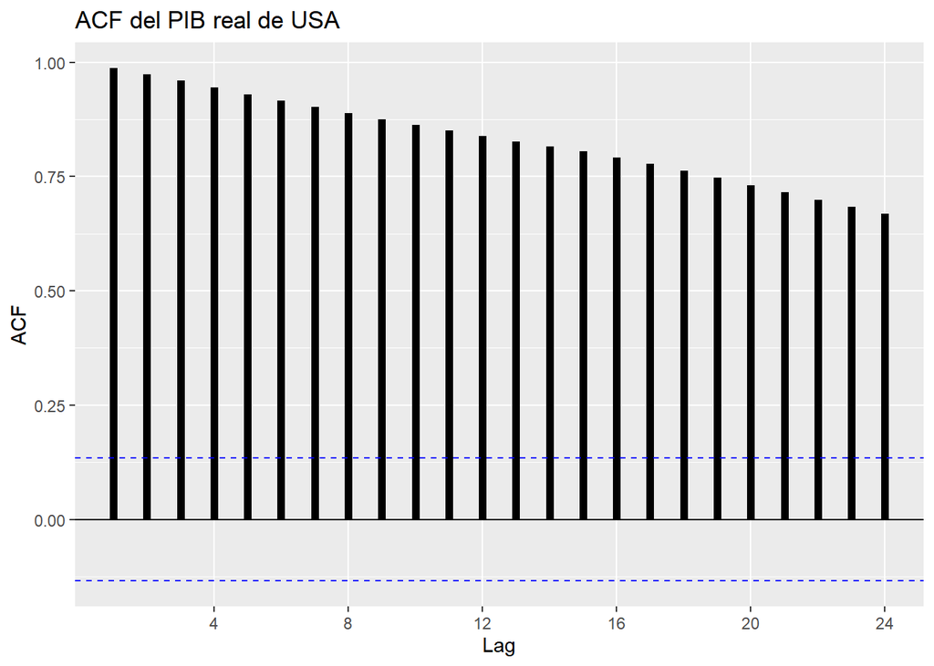

```r
x11()
ggAcf(indprod,lag.max=lags,plot=T,lwd=2) + ggtitle("ACF del PIB real de USA")
```

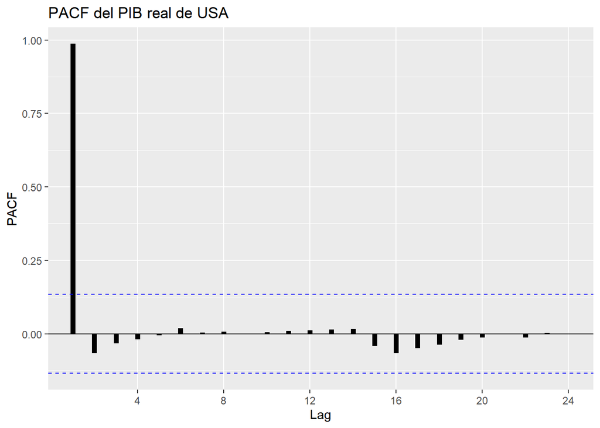

```r
ggPacf(indprod,lag.max=lags,plot=T,lwd=2) + ggtitle("PACF del PIB real de USA")
```

Una tercera alternativa es la ofrecida por el paquete astsa (sirve tanto para objetos ts como xts)

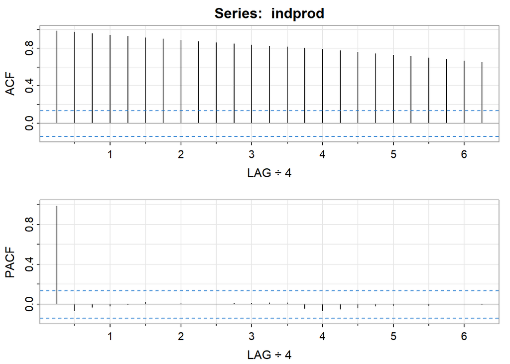

```
##      [,1]  [,2]  [,3]  [,4]  [,5] [,6] [,7] [,8] [,9] [,10] [,11] [,12] [,13]
## ACF  0.99  0.97  0.96  0.94  0.93 0.92  0.9 0.89 0.88  0.86  0.85  0.84  0.83
## PACF 0.99 -0.07 -0.03 -0.02 -0.01 0.02  0.0 0.01 0.00  0.00  0.01  0.01  0.02
##      [,14] [,15] [,16] [,17] [,18] [,19] [,20] [,21] [,22] [,23] [,24] [,25]
## ACF   0.82  0.81  0.79  0.78  0.76  0.75  0.73  0.71  0.70  0.68  0.67  0.65
## PACF  0.02 -0.04 -0.07 -0.05 -0.04 -0.02 -0.01  0.00 -0.01  0.00  0.00 -0.01
```

```r
acf2(indprod)
```

Realizando un análisis econométrico, podemos ver que la FAC tiene un decaimiento lento a cero (lineal) lo que sugiere que el proceso es NO estacionario.

Para estacionalizar la serie, es estándar en la práctica hacer tres transformaciones para ello:

1. Diferenciar la serie y eliminar la tendencia estocástica.

```r
d.indprod= diff(indprod) # serie diferenciada
```

2. Aplicar logaritmo natural y estabilizar la varianza.

```r
l.indprod=log(indprod)
```

3. Diferenciar y estabilizar la serie (tasa de crecimiento).

```r
dl.indprod= diff(log(indprod))*100
```

Vamos a graficar ahora su nivel, su variación, su tasa de crecimiento y su valor en logaritmos.

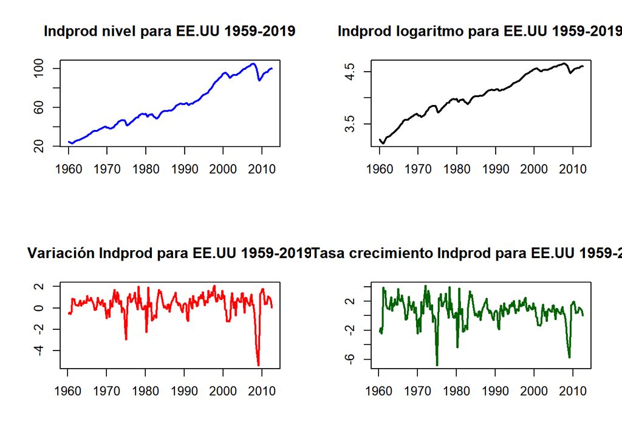

```r
x11()
par(mfrow=c(2,2))
plot.ts(indprod, xlab="",ylab="", main="Indprod nivel para EE.UU 1959-2019",lty=1, lwd=2, col="blue")
plot.ts(l.indprod, xlab="",ylab="", main="Indprod logaritmo para EE.UU 1959-2019",lty=1, lwd=2, col="black")
plot.ts(d.indprod, xlab="",ylab="", main="Variación Indprod para EE.UU 1959-2019",lty=1, lwd=2, col="red")
plot.ts(dl.indprod, xlab="",ylab="", main="Tasa crecimiento Indprod para EE.UU 1959-2019",lty=1, lwd=2, col="darkgreen")
```

Elegimos la tasa de crecimiento de la producción industrial real (Indprod) dada su estabilidad en varianza y media, pese a tener la misma media constante que la serie en primera diferencia.

Analicemos los correlogramas para verficar que sea un proceso débilmente estacionario.

- Nativo:

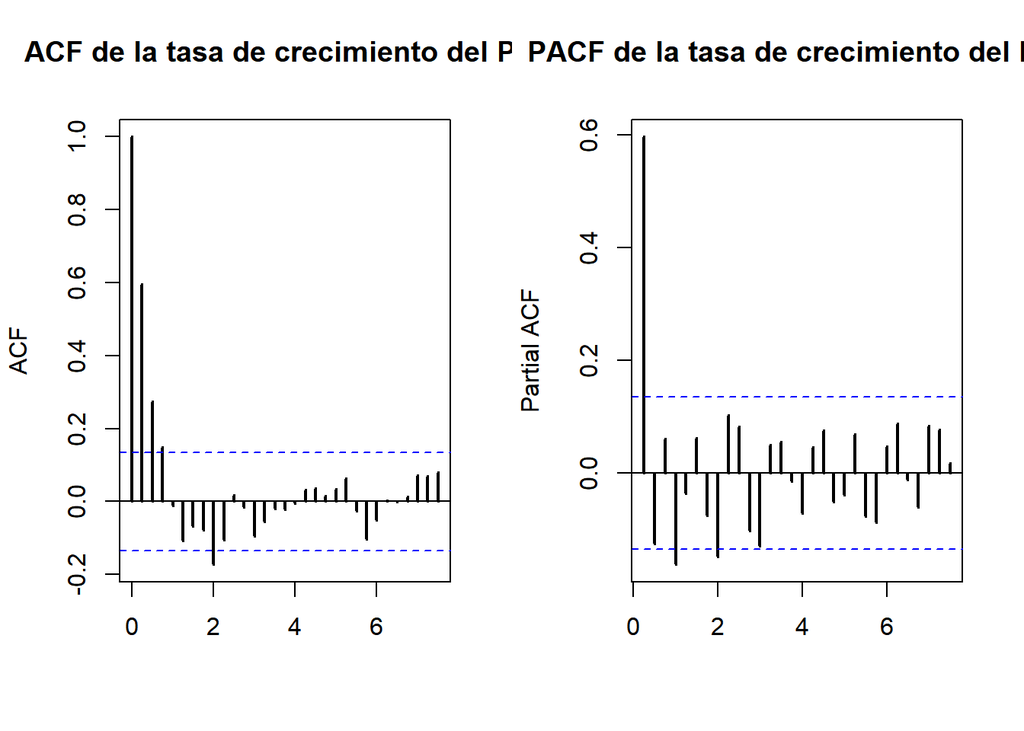

```r
lags=30
par(mfrow=c(1,2))
acf(dl.indprod,lag.max=lags,plot=T,lwd=2,xlab='',main='ACF de la tasa de crecimiento del PIB')
pacf(dl.indprod,lag.max=lags,plot=T,lwd=2,xlab='',main='PACF de la tasa de crecimiento del PIB')
```

- Ggplot2:

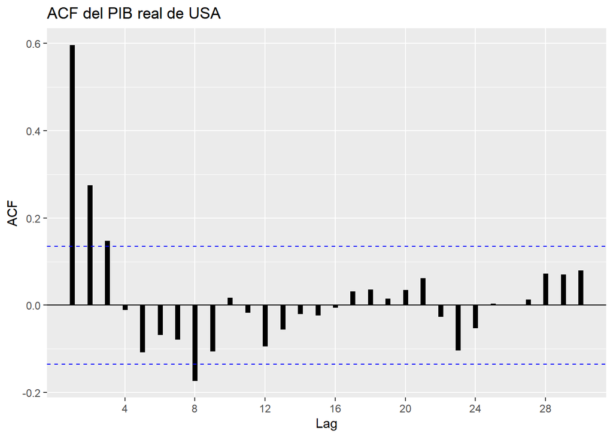

```r
ggAcf(dl.indprod,lag.max=lags,plot=T,lwd=2) + ggtitle("ACF del PIB real de USA")
```

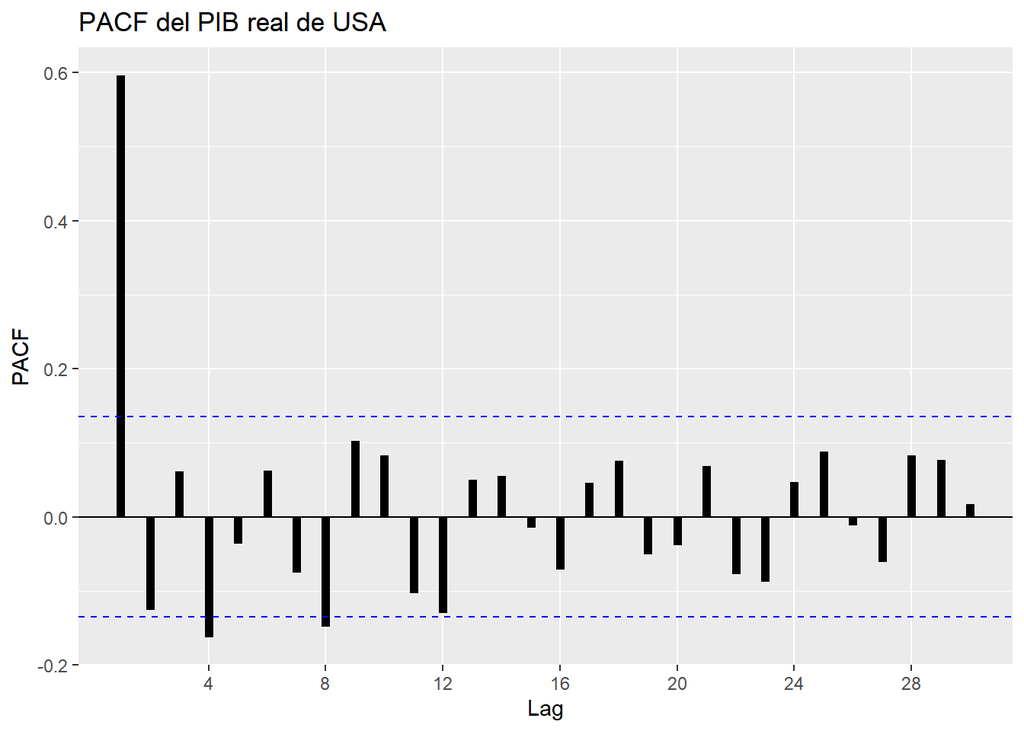

```r
ggPacf(dl.indprod,lag.max=lags,plot=T,lwd=2) + ggtitle("PACF del PIB real de USA")
```

- Paquete astsa:

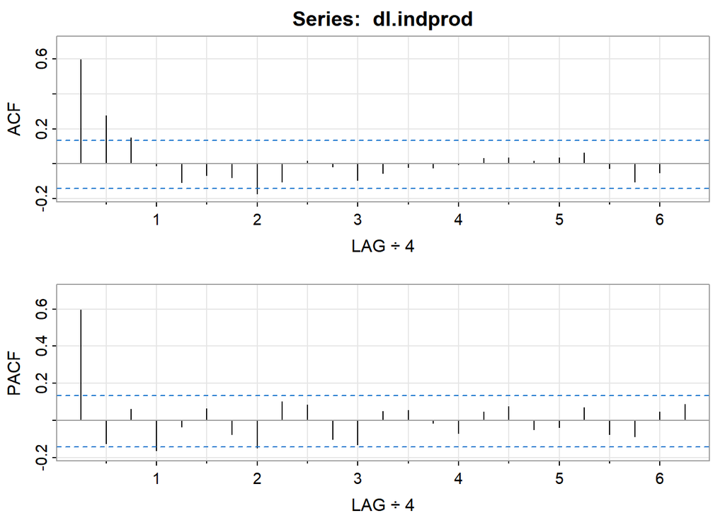

```
##      [,1]  [,2] [,3]  [,4]  [,5]  [,6]  [,7]  [,8]  [,9] [,10] [,11] [,12]
## ACF   0.6  0.27 0.15 -0.01 -0.11 -0.07 -0.08 -0.17 -0.11  0.02 -0.02 -0.09
## PACF  0.6 -0.13 0.06 -0.16 -0.04  0.06 -0.08 -0.15  0.10  0.08 -0.10 -0.13
##      [,13] [,14] [,15] [,16] [,17] [,18] [,19] [,20] [,21] [,22] [,23] [,24]
## ACF  -0.06 -0.02 -0.02 -0.01  0.03  0.04  0.02  0.03  0.06 -0.03 -0.10 -0.05
## PACF  0.05  0.06 -0.01 -0.07  0.05  0.08 -0.05 -0.04  0.07 -0.08 -0.09  0.05
##      [,25]
## ACF   0.00
## PACF  0.09
```

```r
acf2(dl.indprod)
```

### 1.2.3 Criterios de información

Como es sabido por ustedes, en el proceso de identificación también se debe identificar el orden de rezagos del proceso haciendo uso de los **Criterios de información AIC y BIC**, sin desconocer que existen otros como CV o HQIC.

- Método manual

Debemos fijar un orden máximo de rezagos del componente autorregresivo (AR) y del componente de media movil (MA)

```r
AR.m <- 6 #Supondremos rezago autorregresivo máximo de 6 (pmax)
MA.m <- 6 #Supondremos rezago de media móvil máximo de 6. (qmax)
```

1. La siguiente función me permite crear un data frame para distintos modelos ARIMA(p,d,q) en donde cada fila del DataFrame me da el orden del modelo y los AIC y BIC correspondientes a dicho modelo.

**Ojo:** utlizar method = “ML” dentro de arima(), de lo contrario les arrojará error. Con esto le especificamos a R que la estimación se haga por medio de Máxima Verosimilitud.

```r
arma_seleccion_df = function(ts_object, AR.m, MA.m, d, bool_trend, metodo){
  index = 1
  df = data.frame(p = double(), d = double(), q = double(), AIC = double(), BIC = double())
  for (p in 0:AR.m) {
    for (q in 0:MA.m)  {
      fitp <- arima(ts_object, order = c(p, d, q), include.mean = bool_trend,
                    method = metodo)
      df[index,] = c(p, d, q, AIC(fitp), BIC(fitp))
      index = index + 1
    }
  }
  return(df)
}
```

2. Creo la función arma_min_AIC para seleccionar el mejor modelo según AIC.

```r
arma_min_AIC = function(df){
  df2 = df %>%
    filter(AIC == min(AIC))
  return(df2)
}
```

3. Creo la función arma_min_BIC para seleccionar el mejor modelo según BIC

```r
arma_min_BIC = function(df){
  df2 = df %>%
    filter(BIC == min(BIC))
  return(df2)
}
```

Aplicamos la función *arma_selection_df* para construir un data frame con todos los posibles modelos ARIMA(p, d, q) donde p y q varían entre 0 y 6.

Primero,trabajo con la serie en logaritmo, la cual necesita de una diferenciación para ser estacionaria (por eso d=1).

```r
mod_d1_indprod = arma_seleccion_df(l.indprod, AR.m, MA.m, d = 1, TRUE, "ML")
view(mod_d1_indprod)
```

Selecciono el mejor modelo según Criterios de Información cuando d=1.

```r
min_aic_lindprod = arma_min_AIC(mod_d1_indprod); min_aic_lindprod #ARIMA (3,1,5)
```

```
##   p d q       AIC     BIC
## 1 3 1 5 -1240.424 -1210.3
```

```r
min_bic_lindprod = arma_min_BIC(mod_d1_indprod); min_bic_lindprod #ARIMA (1,1,0)
```

```
##   p d q       AIC       BIC
## 1 1 1 0 -1222.678 -1215.984
```

Recuerden que el Criterio BIC prima la parsimonia, por lo que penaliza un número de rezagos muy alto.

Ahora voy a usar la serie ya diferenciada y con logaritmo (**dl_indprod**), por lo que debemos especificar d=0.

```r
mod_d0_indprod = arma_seleccion_df(dl.indprod, AR.m, MA.m, d = 0, TRUE, "ML")
view(mod_d0_indprod)
```

Selecciono el mejor modelo según criterios de información cuando d=0

```r
min_aic_dlindprod = arma_min_AIC(mod_d0_indprod); min_aic_dlindprod #ARIMA (2,0,4)
```

```
##   p d q      AIC     BIC
## 1 2 0 4 688.1861 714.963
```

```r
min_bic_dlindprod = arma_min_BIC(mod_d0_indprod); min_bic_dlindprod #ARIMA (2,0,4)
```

```
##   p d q      AIC     BIC
## 1 2 0 4 688.1861 714.963
```

- Método Automático

También es posible realizar el proceso mediante el comando auto.arima() del paquete forecast

Nota: La misma función auto.arima es capaz de reconocer el orden de diferenciación para que la serie quede estacionaria. En realidad, la función auto.arima calcula un modelo SARIMA porque además de modelar la parte ARIMA de la serie, también modela la componente estacional de la misma.

Para mayor info. sobre los modelos SARIMA: Ver Enders Capítulo 2 - Sección 11: Seasonality.

```r
auto.arima(l.indprod, method = "ML")
```

```
## Series: l.indprod
## ARIMA(1,1,0)(2,0,1)[4] with drift
##
## Coefficients:
##          ar1    sar1     sar2     sma1   drift
##       0.6354  0.6265  -0.1865  -0.7398  0.0066
## s.e.  0.0542  0.1341   0.0796   0.1244  0.0011
##
## sigma^2 = 0.000153:  log likelihood = 626.23
## AIC=-1240.46   AICc=-1240.05   BIC=-1220.38
```

###### **Nota Importante:** En la práctica, lo mejor es usar tanto el método manual como el auto.arima. Basarse exclusivamente en el modelo auto.arima generalmente conduce a conlusiones erroneas, por lo que no basta solo usar el modelo auto.arima. El método manual siempre debe realizarse y debe ser la principal guía, el *auto.arima* debe verse como un método de identificación complementario.

Tambien es muy importante hacer uso de todas las herramientas que se disponen para seleccionar un modelo ARIMA; la gráfica de la serie, las ACF y la PACF, y los Criterios de información.

Sin embargo, de acá en adelante utilizaremos los modelos que se obtuvieron utilizando el Criterio de Información BIC. Pese a que en series de tiempo es más común usar BIC para seleccionar el modelo, se aconseja también observar los resultados cuando se escoge el modelo propuesto por el AIC.

## 1.3 Estimación

Una vez se ha identificado la serie, se procede a estimar el modelo ARIMA.

Debe tomarse en cuenta que incluir muy pocos rezagos puede llevar a que los residuales del modelo no se comporten como un Ruido Blanco, y que incluir muchos parámetros puede llevar a que nuestro modelo no sea parsimonioso; se pierdan muchos grados de libertad y se pierda eficiencia.

Existen 3 métodos de estimación para la función arima: (por default los 3 comandos utilizan CSS)

1. ML: Máxima verosimilitud (más preciso y usualmente la mejor opción para bases pequeñas donde se pueda encontrar una solución analítica). Sin embargo, en ocasiones puede no converger.
2. CSS: (más veloz generalmente. se usa como aproximación o para bases de datos grandisimas). Una desventaja es que puede no hacer estimaciones lo suficientemente precisas y arrojar error.
3. CSS-ML: Una combinación de ambas.

Para más información ver: https://stats.stackexchange.com/questions/209730/fitting-methods-in-arima#

En términos de código, podemos realizar la estimación mediante 3 funciones distintas:

- arima: función del paquete stats que es la más usual emplear y sirve para hacer predicciones con la función forecast del paquete forecast.
- Arima: función del paquete forecast que es básicamente un wrapper de la función arima.
- sarima: función del paquete astsa que permite estimar modelos sarima.

Tanto la función Arima como la función sarima están construidas sobre la función arima().

Cualquier de las 3 funciones para estimar un ARIMA permiten estimar modelos SARIMA es decir, son capaces de modelar la componente estacional de una serie.

Cómo ya se indicó previamente, para mayor precisión en las estimaciones,y para evitar algunos inconvenientes que a veces ocurren al utilizar el método CSS, la estimación del arima se hará mediante maxima verosimilitud (ML).

```r
arima_1.1.0_lindprod = arima(l.indprod, order = c(1,1,0), include.mean = T, method = "ML"); summary(arima_1.1.0_lindprod) # modelamiento ARIMA (1,1,0)
```

```
##
## Call:
## arima(x = l.indprod, order = c(1, 1, 0), include.mean = T, method = "ML")
##
## Coefficients:
##          ar1
##       0.6607
## s.e.  0.0516
##
## sigma^2 estimated as 0.0001696:  log likelihood = 613.34,  aic = -1222.68
##
## Training set error measures:
##                       ME       RMSE         MAE        MPE      MAPE      MASE
## Training set 0.002292243 0.01299491 0.009033742 0.06008416 0.2299317 0.6574251
##                    ACF1
## Training set 0.02181172
```

```r
arima_2.0.4_dlindprod = arima(dl.indprod, order = c(2,0,4), include.mean = T, method = "ML"); summary(arima_2.0.4_dlindprod) # modelamiento ARIMA (2,0,4)
```

```
##
## Call:
## arima(x = dl.indprod, order = c(2, 0, 4), include.mean = T, method = "ML")
##
## Coefficients:
##           ar1      ar2     ma1     ma2     ma3     ma4  intercept
##       -0.3073  -0.7872  0.9986  1.3687  0.8837  0.3530     0.6575
## s.e.   0.0846   0.0686  0.0969  0.1033  0.0819  0.0801     0.1804
##
## sigma^2 estimated as 1.424:  log likelihood = -336.09,  aic = 688.19
##
## Training set error measures:
##                       ME     RMSE       MAE      MPE     MAPE      MASE
## Training set 0.004610456 1.193381 0.8664335 21.20172 115.3604 0.8906004
##                    ACF1
## Training set 0.01005822
```

Finalmente sintetizamos los resultados mediante la función stargazer.

```r
stargazer(arima_1.1.0_lindprod, arima_2.0.4_dlindprod, type = "text")
```

```
##
## ==============================================
##                       Dependent variable:
##                   ----------------------------
##                     l.indprod     dl.indprod
##                        (1)            (2)
## ----------------------------------------------
## ar1                  0.661***      -0.307***
##                      (0.052)        (0.085)
##
## ar2                                -0.787***
##                                     (0.069)
##
## ma1                                0.999***
##                                     (0.097)
##
## ma2                                1.369***
##                                     (0.103)
##
## ma3                                0.884***
##                                     (0.082)
##
## ma4                                0.353***
##                                     (0.080)
##
## intercept                          0.658***
##                                     (0.180)
##
## ----------------------------------------------
## Observations           210            210
## Log Likelihood       613.339       -336.093
## sigma2                0.0002         1.424
## Akaike Inf. Crit.   -1,222.678      688.186
## ==============================================
## Note:              *p<0.1; **p<0.05; ***p<0.01
```

El parámetro “type” dentro de esta función permite obtener tablas en el formato requerido (Ej: LaTeX)

# 2. Spread entre la tasa de bonos norteamericanos a 5 años y T bills

## 2.1 Descripción

Esta serie considera el spread entre la tasa de interés del bono del tesoro de los Estados Unidos a 5 años y la tasa de interés de los Tbills a 3 meses.

Fuente: http://time-series.net/data_sets (Tomados de la página oficial de Walter Enders)

## 2.2 Identificación

### 2.2.1 Importación

Importamos la base de datos correspondiente de esta sección.

```r
quarterly <- read_excel(file.choose())
```

Como vamos a manejar un spread, la diferencia entre el tipo de interés de los bonos del Estado de EE.UU. a 5 años (r5) y el tipo de las letras del Tesoro a 3 meses (government bonds) puede generarse mediante métodos de manipulación de dataframes como el *“pipe”* %>% del paquete Dplyr.

Cabe mencionar, que vamos a importarlo como un objeto tipo xts.

```r
quarterly = quarterly %>%
  mutate(spread = r5 - Tbill)

spread = xts(quarterly$spread, order.by = quarterly$DATE)
```

### 2.2.2 Gráficos y Estacionariedad

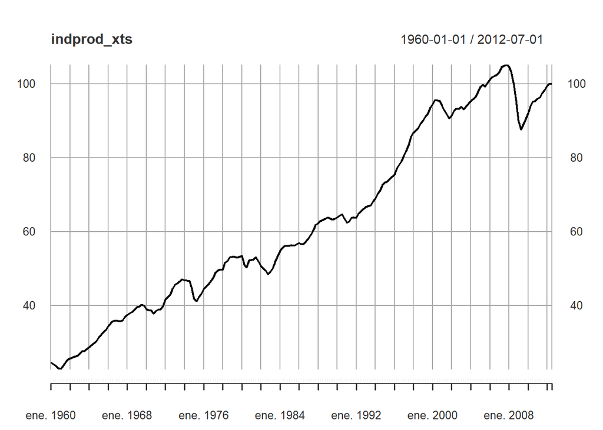

```r
x11()
plot(indprod_xts)
```

Ahora se grafican los correlogramas.

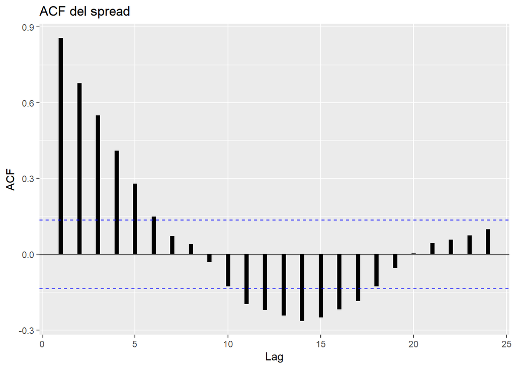

```r
lags=24
ggAcf(spread,lag.max=lags,plot=T,lwd=2) + ggtitle("ACF del spread")
```

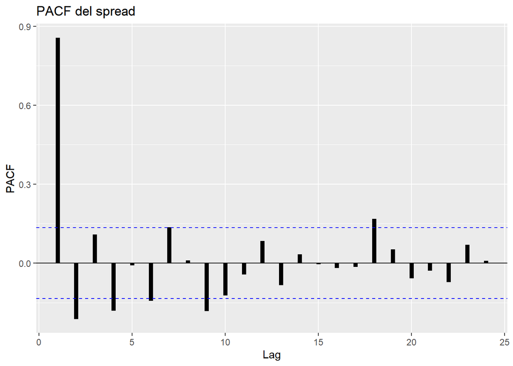

```r
ggPacf(spread,lag.max=lags,plot=T,lwd=2) + ggtitle("PACF del spread")
```

Como se puede observar la serie tiene un decaimiento rápido/geométrico a cero, lo que nos da indicios de la estacionariedad de la serie.

### 2.2.3 Criterios de Información

Aplicamos las funciones explicadas en la sección 1.

Para esta ocasión seleccionamos un máximo de 8 rezagos.

```r
AR.m = 8; MA.m = 8

df_criterios_info_spread = arma_seleccion_df(spread, AR.m, MA.m, d = 0, TRUE, "ML")

min_aic_spread = arma_min_AIC(df_criterios_info_spread); min_aic_spread
```

```
##   p d q      AIC      BIC
## 1 5 0 5 280.4789 320.7579
```

```r
min_bic_spread = arma_min_BIC(df_criterios_info_spread); min_bic_spread
```

```
##   p d q      AIC      BIC
## 1 1 0 1 293.4969 306.9233
```

El criterio AIC selecciona un ARMA (5,5) mientras que el BIC, gracias a su penalización por parámetros, selecciona un ARMA (1,1).

El modelo con el menor BIC es un ARIMA(1,0,1), no obstante, ese modelo no satisface el supuesto de no correlacion serial en los residuales por lo que es necesario utilizar el modelo con el segundo menor BIC, el cual es un ARIMA(1,0,2)*.

Además, si revisamos la PACF, parece oscilar a partir del rezago 2, por tanto es plausible suponer que el grado q es igual a 2.

Por auto.arima:

```r
auto.arima(spread, method = "ML")
```

```
## Series: spread
## ARIMA(1,0,3) with non-zero mean
##
## Coefficients:
##          ar1     ma1      ma2     ma3    mean
##       0.7788  0.3152  -0.0776  0.1246  1.1905
## s.e.  0.0645  0.0896   0.0882  0.0716  0.1933
##
## sigma^2 = 0.2217:  log likelihood = -139.4
## AIC=290.8   AICc=291.21   BIC=310.94
```

## 2.3 Estimación

Usaremos la función arima(), dadas las otras opciones presentadas en el aprtado 1.

```r
arima_1.0.2_spread = arima(spread,
                       order = c(1,0,2), include.mean = T,
                       method = "ML"); summary(arima_1.0.2_spread)
```

```
##
## Call:
## arima(x = spread, order = c(1, 0, 2), include.mean = T, method = "ML")
##
## Coefficients:
##          ar1     ma1      ma2  intercept
##       0.8206  0.3060  -0.1543     1.1889
## s.e.  0.0520  0.0826   0.0768     0.2024
##
## sigma^2 estimated as 0.2196:  log likelihood = -140.89,  aic = 291.78
##
## Training set error measures:
##                       ME      RMSE       MAE  MPE MAPE      MASE        ACF1
## Training set 0.002521685 0.4685631 0.3370209 -Inf  Inf 0.9533639 -0.01556189
```

Imprimimos el resultado.

```r
stargazer(arima_1.0.2_spread, type = "text")
```

```
##
## =============================================
##                       Dependent variable:
##                   ---------------------------
##                             spread
## ---------------------------------------------
## ar1                        0.821***
##                             (0.052)
##
## ma1                        0.306***
##                             (0.083)
##
## ma2                        -0.154**
##                             (0.077)
##
## intercept                  1.189***
##                             (0.202)
##
## ---------------------------------------------
## Observations                  212
## Log Likelihood             -140.892
## sigma2                       0.220
## Akaike Inf. Crit.           291.784
## =============================================
## Note:             *p<0.1; **p<0.05; ***p<0.01
```

# 3. Tasa de desempleo mensual EE.UU (1959 - 2012)

## 3.1 Descripción

Para el último ejemplo vamos a trabajar con la serie de la Tasa de desempleo mensual para Estados Unidos de 1959 a 2012. Este indicador económico mide el porcentaje de la población económicamente activa que se encuentra desempleada. Para el caso estadounidense, se toma a la población económicamente activa (labor force) como todas aquellas personas de 16 o más años, que en alguno de los 50 estados, se encuentren en capacidad de trabajar. La forma de calcularlo es: (población desocupada/población económicamente activa)*100.

Fuente: https://fred.stlouisfed.org/series/UNRATE (Tomado de la FRED de la Reserva Federal de St Louis)

## 3.2 Identificación

### 3.2.1 Importación

Importamos la serie de tiempo.

```r
base_unem <- read_excel(file.choose())
```

La convertimos en objeto tipo ts y visualizamos.

```r
UNRATE = ts(base_unem$UNRATE, start = c(1959,11),
            frequency = 12) # Inicia en Noviembre de 1959 con periodicidad mensual

View(UNRATE)
```

Creamos un objeto xts.

```r
UNRATE_xts = xts(base_unem$UNRATE,
                 order.by = base_unem$observation_date)
```

### 3.2.2 Gráficos y Estacionariedad

Graficamos la serie con la funcion del paquete stats de R.

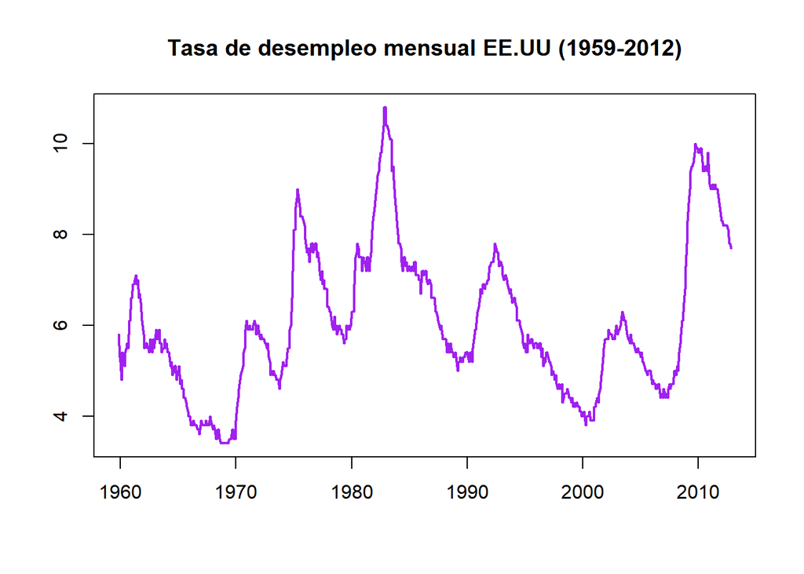

```r
x11()
plot.ts(UNRATE, xlab="",ylab="", main="Tasa de desempleo mensual EE.UU (1959-2012)",lty=1, lwd=2, col="purple")
```

Para el objeto xts.

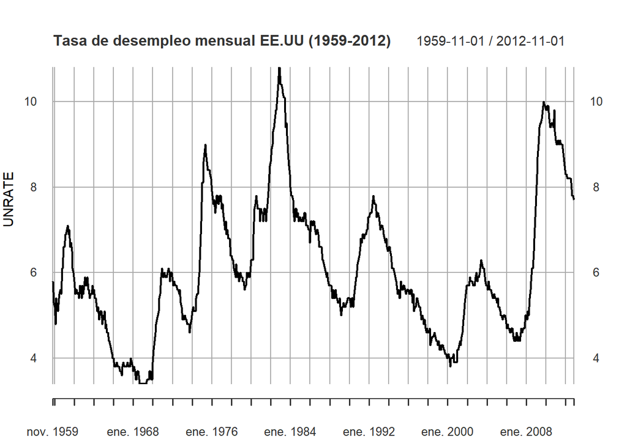

```r
x11()
plot(UNRATE_xts, main = "Tasa de desempleo mensual EE.UU (1959-2012)", ylab  = "UNRATE")
```

La grafica de la serie no muestra el comportamiento tipico de una serie estacionaria, puesto que si bien se podria afirmar que su varianza es estable, lo mismo no parece ser cierto para su media.

Graficamos las FAC y FACP de la serie en nivel.

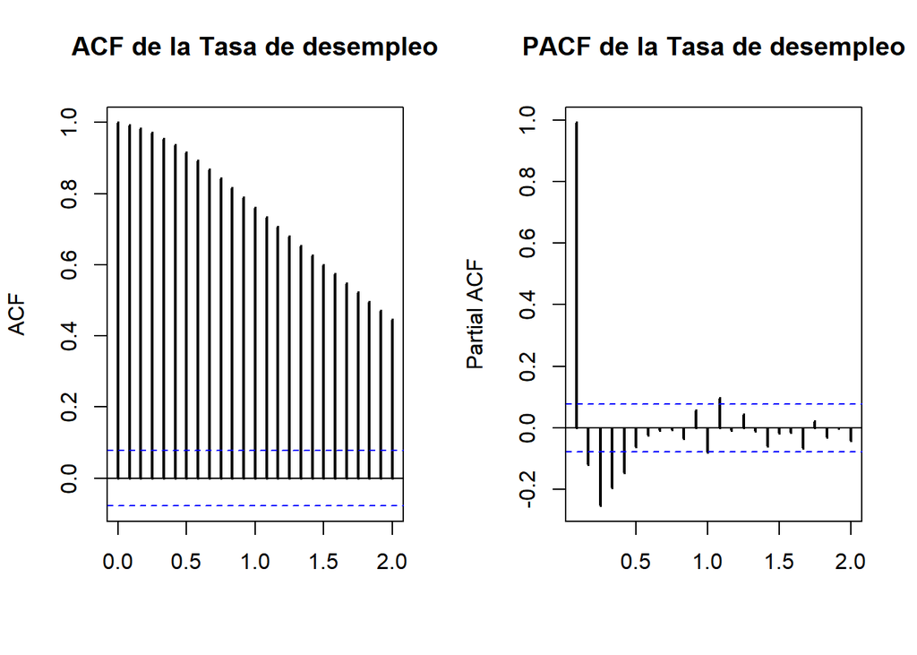

```r
lags=24
par(mfrow=c(1,2))
acf(UNRATE,lag.max=lags,plot=T,lwd=2,xlab='',main='ACF de la Tasa de desempleo')
pacf(UNRATE,lag.max=lags,plot=T,lwd=2,xlab='',main='PACF de la Tasa de desempleo')
```

Igualmente, en la grafica FAC presenta un decaimiento a cero pero este es muy lento, propio de un proceso altamente persistente. Por tanto, se asume que la serie no es estacionaria y se hace necesario realizar las transformaciones explicadas anteriormente.

Como su varianza es estable, es pertinente estabilizar únicamente su media mediante una diferenciación.

```r
d.UNRATE = diff(UNRATE) # serie diferenciada
```

Realicemos una comparación entre las gráficas la serie original en nivel y su variación.

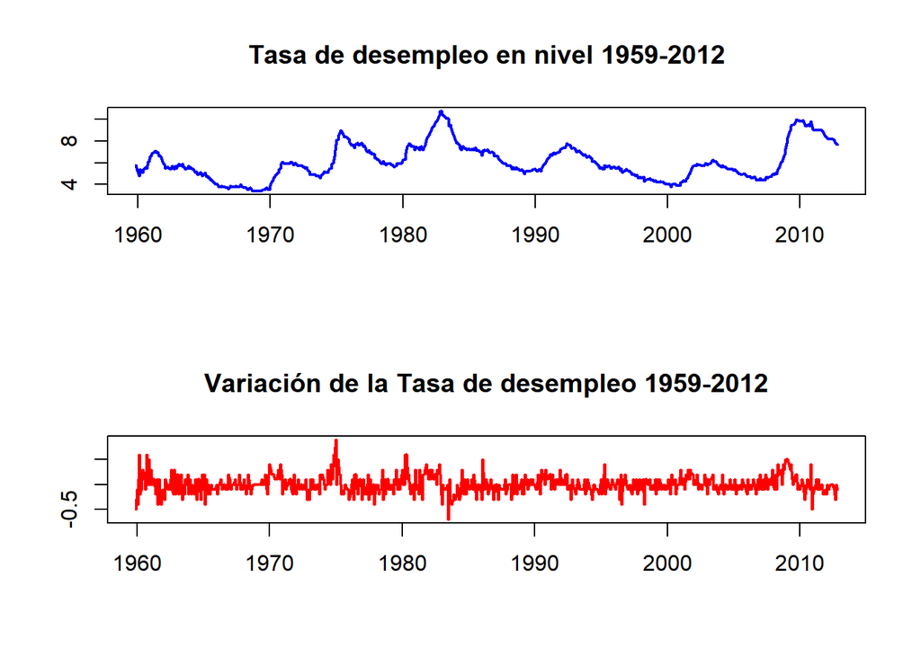

```r
x11()
par(mfrow=c(2,1))
plot.ts(UNRATE, xlab="",ylab="", main="Tasa de desempleo en nivel 1959-2012",
        lty=1, lwd=2, col="blue")
plot.ts(d.UNRATE, xlab="",ylab="", main="Variación de la Tasa de desempleo 1959-2012",lty=1,
        lwd=2, col="red")
```

Grafiquemos la FAC y FACP para la serie diferenciada.

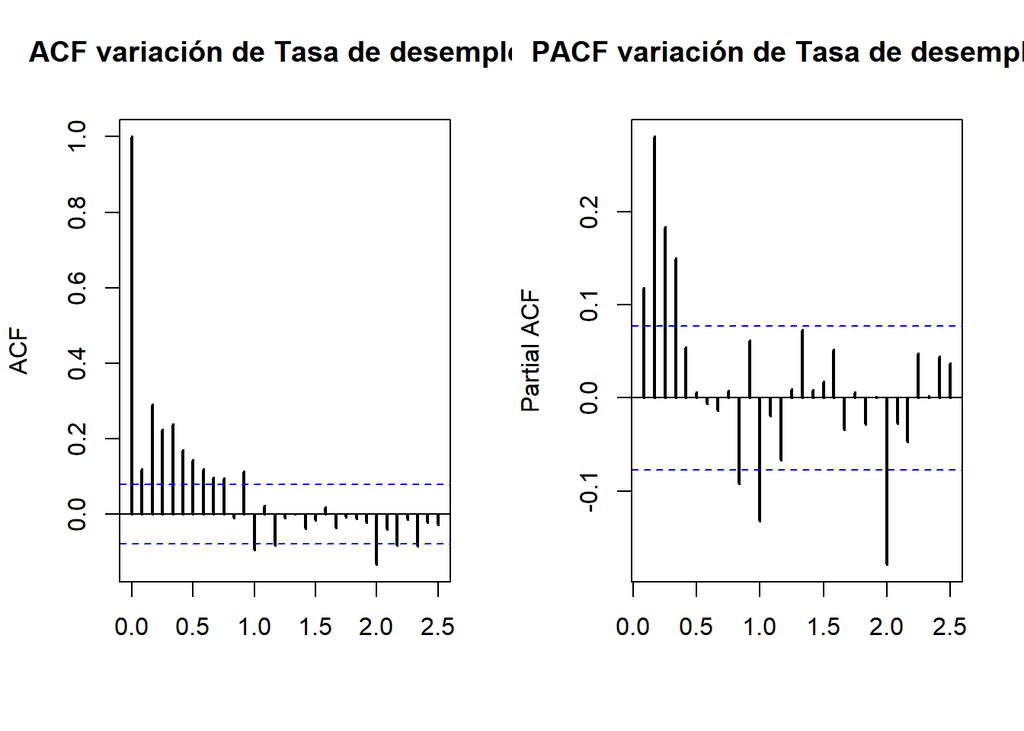

```r
x11()
lags=30
par(mfrow=c(1,2))
acf(d.UNRATE,lag.max=lags,plot=T,lwd=2,xlab="",main="ACF variación de Tasa de desempleo")
pacf(d.UNRATE,lag.max=lags,plot=T,lwd=2,xlab="",main="PACF variación de Tasa de desempleo")
```

La gráfica de la variación del Tasa de desempleo, contrario a su version en niveles, evidencia claramente una media contante mientras que en la ACF ya no se presenta alta persistencia, por lo que se asume que la serie transformada es estacionaria.

Nuevamente, usamos las funciones del apartado inicial, predisponiendo de un máximo de 6 rezagos para los ordenes p y q. Recordemos las características de dichas funciones:

- arma_seleccion_df: función que me ordena en un data.frame todos los posibles grados p y q dado los Criterios de Información AIC y BIC.
- arma_min_AIC: seleccionar el mejor modelo según AIC, es decir, el menor.
- arma_min_BIC: seleccionar el mejor modelo según BIC, es decir, el menor.

Como diferenciamos la serie, recordemos que dicho proceso se puede hacer manualmente o con la indicación (d=1).

1. Serie en niveles (con d=1):

```r
AR.m = 6; MA.m = 6

mod_d1_UNRATE = arma_seleccion_df(UNRATE, AR.m, MA.m, d = 1, TRUE, "ML"); view(mod_d1_UNRATE)

# Selecciono el mejor modelo según criterios de información cuando d=1
min_aic_UNRATE = arma_min_AIC(mod_d1_UNRATE); min_aic_UNRATE #ARIMA (6,1,6)
```

```
##   p d q       AIC       BIC
## 1 6 1 6 -464.7892 -406.8716
```

```r
min_bic_UNRATE = arma_min_BIC(mod_d1_UNRATE); min_bic_UNRATE #ARIMA (1,1,2)
```

```
##   p d q      AIC       BIC
## 1 1 1 2 -454.773 -436.9522
```

2. Serie diferenciada (con d=0)

```r
mod_d0_UNRATE = arma_seleccion_df(d.UNRATE, AR.m, MA.m, d = 0, TRUE, "ML"); view(mod_d0_UNRATE)

# Selecciono el mejor modelo según criterios de información cuando d=1
min_aic_d.UNRATE = arma_min_AIC(mod_d0_UNRATE); min_aic_d.UNRATE #ARIMA (6,0,6)
```

```
##   p d q       AIC       BIC
## 1 6 0 6 -462.8001 -400.4273
```

```r
min_bic_d.UNRATE = arma_min_BIC(mod_d0_UNRATE); min_bic_d.UNRATE #ARIMA (1,0,2)
```

```
##   p d q       AIC       BIC
## 1 1 0 2 -452.7745 -430.4985
```

En este caso nos guiamos por el criterio AIC, porque la ACF y la PACF muestran que el valor en el periodo actual depende en varios periodos pasados, por lo que conviene escoger un mayor numero de rezagos para evitar violar el supuesto de no autocorrelacion. Por tanto seleccionamos el modelo ARIMA(6,0,6) (para la serie diferenciada).*

Como método complementario analizamos con el comando auto.arima.

```r
auto.arima(UNRATE, method = "ML")
```

```
## Series: UNRATE
## ARIMA(1,1,2)(2,0,1)[12]
##
## Coefficients:
##          ar1      ma1     ma2    sar1     sar2     sma1
##       0.8829  -0.8946  0.2139  0.5019  -0.0836  -0.7203
## s.e.  0.0330   0.0496  0.0417  0.0941   0.0531   0.0871
##
## sigma^2 = 0.02619:  log likelihood = 257.33
## AIC=-500.66   AICc=-500.48   BIC=-469.47
```

## 3.3 Estimación

Estimamos las dos variantes del modelo.

```r
arima_6.1.6_UNRATE = arima(UNRATE,
                           order = c(6,1,6), include.mean = T,
                           method = "ML"); summary(arima_6.1.6_UNRATE)
```

```
##
## Call:
## arima(x = UNRATE, order = c(6, 1, 6), include.mean = T, method = "ML")
##
## Coefficients:
##           ar1     ar2     ar3     ar4     ar5      ar6     ma1      ma2
##       -0.1746  0.2478  0.1735  0.5275  0.2362  -0.6420  0.2011  -0.0530
## s.e.   0.0885  0.0806  0.0442  0.0471  0.0800   0.0812  0.0846   0.0796
##           ma3      ma4      ma5     ma6
##       -0.0153  -0.3397  -0.1765  0.7186
## s.e.   0.0554   0.0536   0.0667  0.0742
##
## sigma^2 estimated as 0.02683:  log likelihood = 245.39,  aic = -464.79
##
## Training set error measures:
##                       ME      RMSE       MAE        MPE   MAPE      MASE
## Training set 0.001385414 0.1636779 0.1233146 0.01673007 2.0914 0.9437793
##                    ACF1
## Training set -0.0164705
```

```r
arima_6.0.6_UNRATE = arima(d.UNRATE,
                           order = c(6,0,6), include.mean = T,
                           method = "ML"); summary(arima_6.0.6_UNRATE)
```

```
##
## Call:
## arima(x = d.UNRATE, order = c(6, 0, 6), include.mean = T, method = "ML")
##
## Coefficients:
##           ar1     ar2     ar3     ar4     ar5      ar6     ma1      ma2
##       -0.1749  0.2476  0.1735  0.5278  0.2365  -0.6416  0.2015  -0.0527
## s.e.   0.0888  0.0808  0.0442  0.0471  0.0803   0.0815  0.0850   0.0800
##           ma3      ma4      ma5     ma6  intercept
##       -0.0154  -0.3400  -0.1769  0.7181     0.0016
## s.e.   0.0555   0.0536   0.0668  0.0745     0.0137
##
## sigma^2 estimated as 0.02683:  log likelihood = 245.4,  aic = -462.8
##
## Training set error measures:
##                        ME      RMSE       MAE MPE MAPE      MASE        ACF1
## Training set 0.0006197023 0.1638054 0.1235295 NaN  Inf 0.6738939 -0.01641878
```

Finalmente proyectamos los resultados en la siguiente tabla.

```r
stargazer(arima_6.0.6_UNRATE, arima_6.1.6_UNRATE, type = "text")
```

```
##
## ==============================================
##                       Dependent variable:
##                   ----------------------------
##                      d.UNRATE       UNRATE
##                        (1)            (2)
## ----------------------------------------------
## ar1                  -0.175**      -0.175**
##                      (0.089)        (0.089)
##
## ar2                  0.248***      0.248***
##                      (0.081)        (0.081)
##
## ar3                  0.174***      0.174***
##                      (0.044)        (0.044)
##
## ar4                  0.528***      0.528***
##                      (0.047)        (0.047)
##
## ar5                  0.236***      0.236***
##                      (0.080)        (0.080)
##
## ar6                 -0.642***      -0.642***
##                      (0.081)        (0.081)
##
## ma1                  0.201**        0.201**
##                      (0.085)        (0.085)
##
## ma2                   -0.053        -0.053
##                      (0.080)        (0.080)
##
## ma3                   -0.015        -0.015
##                      (0.056)        (0.055)
##
## ma4                 -0.340***      -0.340***
##                      (0.054)        (0.054)
##
## ma5                 -0.177***      -0.176***
##                      (0.067)        (0.067)
##
## ma6                  0.718***      0.719***
##                      (0.074)        (0.074)
##
## intercept             0.002
##                      (0.014)
##
## ----------------------------------------------
## Observations           636            636
## Log Likelihood       245.400        245.395
## sigma2                0.027          0.027
## Akaike Inf. Crit.    -462.800      -464.789
## ==============================================
## Note:              *p<0.1; **p<0.05; ***p<0.01
```